# Доклад по дисциплине «Основы информационной безопасности»

Классы угроз информационной безопасности

Павличенко Родион Андреевич

1132246838@pfur.ru

Российский университет дружбы народов

Российский университет дружбы народов

# Информация

## Докладчик

- **ФИО:** Павличенко Родион Андреевич
- **Статус:** Cтудент
- **Группа:** НПИбд-02-24
- **ВУЗ:** Российский университет дружбы народов им. П. Лумумбы
- **Почта:**1132246838@pfur.ru

## Актуальность темы

- Информационные системы постоянно подвергаются внешним и внутренним воздействиям.
- Для построения защиты важно понимать, **какие именно угрозы** существуют.
- Классификация угроз помогает перейти от общих рассуждений к конкретным мерам защиты.

# Теоретическая часть

## Цель

Изучить классы угроз информационной безопасности, определить их основные признаки, источники и способы реализации, а также показать значение классификации угроз для построения эффективной системы защиты информации.

## Задачи

1. Определить понятие угрозы информационной безопасности.
2. Рассмотреть основные подходы к классификации угроз.
3. Проанализировать классы угроз по источнику и способу реализации.
4. Изучить угрозы с точки зрения конфиденциальности, целостности и доступности.
5. Показать практическое значение классификации угроз для построения защиты.

## Ключевые понятия (для понимания темы)

- **Угроза** — потенциальная причина инцидента, способная нанести ущерб информации или системе.
- **Уязвимость** — слабое место, через которое угроза может быть реализована.
- **Риск** — вероятность реализации угрозы с учетом возможного ущерба.

## Понятие угрозы информационной безопасности

Угроза информационной безопасности — это совокупность условий и факторов, создающих опасность нарушения защищенности информации или нормального функционирования информационной системы.

## Почему нужна классификация угроз

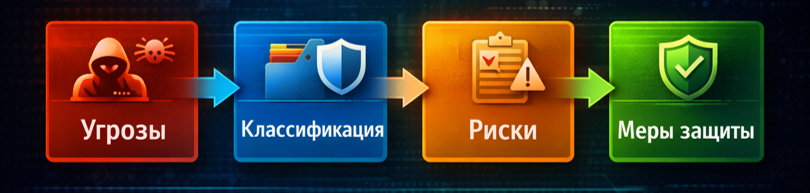

Классификация угроз необходима для того, чтобы: системно оценивать риски; понимать, откуда исходит опасность; выбирать подходящие меры защиты; строить модель угроз для конкретной системы.

## Угрозы по источнику возникновения

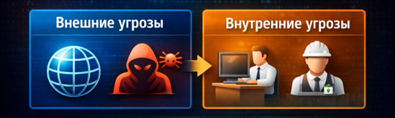

Внешние угрозы — исходят извне организации: сетевые атаки, фишинг, вредоносный трафик, DDoS, попытки взлома. Внутренние угрозы — исходят от сотрудников, подрядчиков, администраторов: ошибки, злоупотребление правами, копирование данных, неправильные настройки.

## Угрозы по характеру возникновения

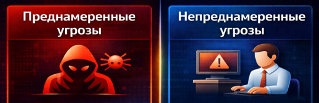

Преднамеренные угрозы — реализуются сознательно: взлом, кража данных, внедрение вредоносного ПО, саботаж. Непреднамеренные угрозы — возникают без злого умысла: ошибки пользователя, неверные настройки, случайное удаление файлов, отправка данных не тому адресату.

## Угрозы по характеру воздействия

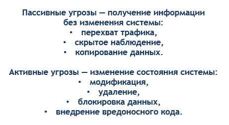

## Модель CIA: основные свойства информации

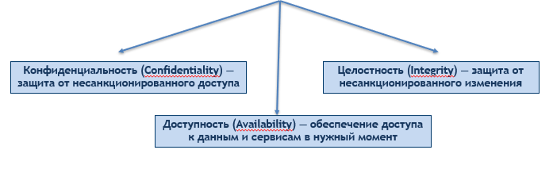

## Примеры угроз в модели CIA

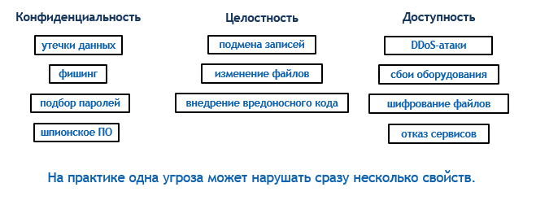

## Практическое значение классификации угроз

- Помогает формировать **модель угроз** для конкретной системы.
- Позволяет правильно расставлять приоритеты в защите.
- Упрощает выбор мер защиты под конкретные классы угроз.
- Повышает качество анализа рисков и реагирования на инциденты.

## Да что там Windows! Самая неотлаженная и глючная система — это жизнь. © Стас Янковский

[figure not shown]